# Python_Group_Project-checkpoint

```python
#importing the important libraries
import pandas as pd
import numpy as np
import matplotlib.pyplot as plt
import seaborn as sns
import warnings
warnings.filterwarnings('ignore')
```

```python
#reading and concatenating the data
df0 = pd.read_csv("2000-01.csv")
df1 = pd.read_csv("2001-02.csv")
df2 = pd.read_csv("2002-03.csv")
df3 = pd.read_csv("2003-04.csv")
df4 = pd.read_csv("2004-05.csv")
df5 = pd.read_csv("2005-06.csv")
df6 = pd.read_csv("2006-07.csv")
df7 = pd.read_csv("2007-08.csv")
df8 = pd.read_csv("2008-09.csv")
df9 = pd.read_csv("2009-10.csv")
df10 = pd.read_csv("2010-11.csv")
df11 = pd.read_csv("2011-12.csv")
df12 = pd.read_csv("2012-13.csv")
df13 = pd.read_csv("2013-14.csv")
df14 = pd.read_csv("2014-15.csv")
df15 = pd.read_csv("2015-16.csv")
df16 = pd.read_csv("2016-17.csv")
df17 = pd.read_csv("2017-18.csv")
df18 = pd.read_csv("2018-19.csv")
df19 = pd.read_csv("2019-20.csv")
```

```python
main_data = pd.concat([df0,df1,df2,df3,df4,df5,df6,df7,df8,df9,df10,df11,df12,df13,df14,df15,df16,df17,df18,df19],ignore_index=True)
```

```python
#top 5 rows
main_data.head()
```

|  | Div | Date | HomeTeam | AwayTeam | FTHG | FTAG | FTR | HTHG | HTAG | HTR | ... | AvgC<2.5 | AHCh | B365CAHH | B365CAHA | PCAHH | PCAHA | MaxCAHH | MaxCAHA | AvgCAHH | AvgCAHA |
| --- | --- | --- | --- | --- | --- | --- | --- | --- | --- | --- | --- | --- | --- | --- | --- | --- | --- | --- | --- | --- | --- |
| 0 | E0 | 19/08/00 | Charlton | Man City | 4 | 0 | H | 2 | 0 | H | ... | NaN | NaN | NaN | NaN | NaN | NaN | NaN | NaN | NaN | NaN |
| 1 | E0 | 19/08/00 | Chelsea | West Ham | 4 | 2 | H | 1 | 0 | H | ... | NaN | NaN | NaN | NaN | NaN | NaN | NaN | NaN | NaN | NaN |
| 2 | E0 | 19/08/00 | Coventry | Middlesbrough | 1 | 3 | A | 1 | 1 | D | ... | NaN | NaN | NaN | NaN | NaN | NaN | NaN | NaN | NaN | NaN |
| 3 | E0 | 19/08/00 | Derby | Southampton | 2 | 2 | D | 1 | 2 | A | ... | NaN | NaN | NaN | NaN | NaN | NaN | NaN | NaN | NaN | NaN |
| 4 | E0 | 19/08/00 | Leeds | Everton | 2 | 0 | H | 2 | 0 | H | ... | NaN | NaN | NaN | NaN | NaN | NaN | NaN | NaN | NaN | NaN |

5 rows × 144 columns

```python
#bottom 5 rows
main_data.tail()
```

|  | Div | Date | HomeTeam | AwayTeam | FTHG | FTAG | FTR | HTHG | HTAG | HTR | ... | AvgC<2.5 | AHCh | B365CAHH | B365CAHA | PCAHH | PCAHA | MaxCAHH | MaxCAHA | AvgCAHH | AvgCAHA |
| --- | --- | --- | --- | --- | --- | --- | --- | --- | --- | --- | --- | --- | --- | --- | --- | --- | --- | --- | --- | --- | --- |
| 7255 | E0 | 15/02/2020 | Norwich | Liverpool | 0 | 1 | A | 0 | 0 | D | ... | 2.67 | 1.50 | 1.82 | 2.11 | 1.83 | 2.10 | 1.96 | 2.14 | 1.85 | 2.01 |
| 7256 | E0 | 16/02/2020 | Aston Villa | Tottenham | 2 | 3 | A | 1 | 2 | A | ... | 2.11 | 0.50 | 1.95 | 1.98 | 1.96 | 1.97 | 1.98 | 2.00 | 1.93 | 1.94 |
| 7257 | E0 | 16/02/2020 | Arsenal | Newcastle | 4 | 0 | H | 0 | 0 | D | ... | 2.18 | -1.25 | 2.05 | 1.88 | 2.05 | 1.88 | 2.09 | 1.89 | 2.02 | 1.86 |
| 7258 | E0 | 17/02/2020 | Chelsea | Man United | 0 | 2 | A | 0 | 1 | A | ... | 1.79 | -0.50 | 2.02 | 1.91 | 2.02 | 1.91 | 2.05 | 2.01 | 1.97 | 1.89 |
| 7259 | E0 | 19/02/2020 | Man City | West Ham | 2 | 0 | H | 1 | 0 | H | ... | 3.84 | -2.50 | 1.94 | 1.96 | 1.93 | 1.98 | 1.98 | 2.05 | 1.92 | 1.95 |

5 rows × 144 columns

```python
#exporting the main data csv file
main_data.to_csv("main_data.csv", index=False)
```

```python
#changing the Date datatype to datetime
main_data['Date'] = pd.to_datetime(main_data['Date'])  # Convert to datetime format

# Create separate columns for Day, Month, and Year
main_data['Year'] = main_data['Date'].dt.year
main_data['Day'] = main_data['Date'].dt.day
main_data['Month'] = main_data['Date'].dt.month
```

```python
main_data.head()
```

|  | Div | Date | HomeTeam | AwayTeam | FTHG | FTAG | FTR | HTHG | HTAG | HTR | ... | B365CAHA | PCAHH | PCAHA | MaxCAHH | MaxCAHA | AvgCAHH | AvgCAHA | Year | Day | Month |
| --- | --- | --- | --- | --- | --- | --- | --- | --- | --- | --- | --- | --- | --- | --- | --- | --- | --- | --- | --- | --- | --- |
| 0 | E0 | 2000-08-19 | Charlton | Man City | 4 | 0 | H | 2 | 0 | H | ... | NaN | NaN | NaN | NaN | NaN | NaN | NaN | 2000 | 19 | 8 |
| 1 | E0 | 2000-08-19 | Chelsea | West Ham | 4 | 2 | H | 1 | 0 | H | ... | NaN | NaN | NaN | NaN | NaN | NaN | NaN | 2000 | 19 | 8 |
| 2 | E0 | 2000-08-19 | Coventry | Middlesbrough | 1 | 3 | A | 1 | 1 | D | ... | NaN | NaN | NaN | NaN | NaN | NaN | NaN | 2000 | 19 | 8 |
| 3 | E0 | 2000-08-19 | Derby | Southampton | 2 | 2 | D | 1 | 2 | A | ... | NaN | NaN | NaN | NaN | NaN | NaN | NaN | 2000 | 19 | 8 |
| 4 | E0 | 2000-08-19 | Leeds | Everton | 2 | 0 | H | 2 | 0 | H | ... | NaN | NaN | NaN | NaN | NaN | NaN | NaN | 2000 | 19 | 8 |

5 rows × 147 columns

```python
#keeping only the required columns
columns_req = [
    'HomeTeam', 'AwayTeam', 'FTHG', 'FTAG', 'HTHG', 'HTAG', 'FTR', 'HTR',
    'HS', 'AS', 'HST', 'AST', 'HF', 'AF', 'HY', 'AY', 'HR', 'AR', 'Referee','Day','Month','Year'
]

# Retaining only the required columns
main_data = main_data[columns_req]

# Display the first few rows to confirm
main_data.head()
```

|  | HomeTeam | AwayTeam | FTHG | FTAG | HTHG | HTAG | FTR | HTR | HS | AS | ... | HF | AF | HY | AY | HR | AR | Referee | Day | Month | Year |
| --- | --- | --- | --- | --- | --- | --- | --- | --- | --- | --- | --- | --- | --- | --- | --- | --- | --- | --- | --- | --- | --- |
| 0 | Charlton | Man City | 4 | 0 | 2 | 0 | H | H | 17 | 8 | ... | 13 | 12 | 1 | 2 | 0 | 0 | Rob Harris | 19 | 8 | 2000 |
| 1 | Chelsea | West Ham | 4 | 2 | 1 | 0 | H | H | 17 | 12 | ... | 19 | 14 | 1 | 2 | 0 | 0 | Graham Barber | 19 | 8 | 2000 |
| 2 | Coventry | Middlesbrough | 1 | 3 | 1 | 1 | A | D | 6 | 16 | ... | 15 | 21 | 5 | 3 | 1 | 0 | Barry Knight | 19 | 8 | 2000 |
| 3 | Derby | Southampton | 2 | 2 | 1 | 2 | D | A | 6 | 13 | ... | 11 | 13 | 1 | 1 | 0 | 0 | Andy D'Urso | 19 | 8 | 2000 |
| 4 | Leeds | Everton | 2 | 0 | 2 | 0 | H | H | 17 | 12 | ... | 21 | 20 | 1 | 3 | 0 | 0 | Dermot Gallagher | 19 | 8 | 2000 |

5 rows × 22 columns

```python
main_data.tail()
```

|  | HomeTeam | AwayTeam | FTHG | FTAG | HTHG | HTAG | FTR | HTR | HS | AS | ... | HF | AF | HY | AY | HR | AR | Referee | Day | Month | Year |
| --- | --- | --- | --- | --- | --- | --- | --- | --- | --- | --- | --- | --- | --- | --- | --- | --- | --- | --- | --- | --- | --- |
| 7255 | Norwich | Liverpool | 0 | 1 | 0 | 0 | A | D | 5 | 17 | ... | 5 | 11 | 1 | 2 | 0 | 0 | S Attwell | 15 | 2 | 2020 |
| 7256 | Aston Villa | Tottenham | 2 | 3 | 1 | 2 | A | A | 18 | 23 | ... | 12 | 10 | 2 | 0 | 0 | 0 | M Atkinson | 16 | 2 | 2020 |
| 7257 | Arsenal | Newcastle | 4 | 0 | 0 | 0 | H | D | 15 | 10 | ... | 15 | 9 | 2 | 0 | 0 | 0 | L Mason | 16 | 2 | 2020 |
| 7258 | Chelsea | Man United | 0 | 2 | 0 | 1 | A | A | 17 | 9 | ... | 11 | 11 | 4 | 3 | 0 | 0 | A Taylor | 17 | 2 | 2020 |
| 7259 | Man City | West Ham | 2 | 0 | 1 | 0 | H | H | 20 | 3 | ... | 5 | 7 | 0 | 1 | 0 | 0 | K Friend | 19 | 2 | 2020 |

5 rows × 22 columns

```python
#checking the descriptive statistics
main_data.describe()
```

|  | FTHG | FTAG | HTHG | HTAG | HS | AS | HST | AST | HF | AF | HY | AY | HR | AR | Day | Month | Year |
| --- | --- | --- | --- | --- | --- | --- | --- | --- | --- | --- | --- | --- | --- | --- | --- | --- | --- |
| count | 7260.000000 | 7260.000000 | 7260.000000 | 7260.000000 | 7260.000000 | 7260.000000 | 7260.000000 | 7260.000000 | 7260.000000 | 7260.000000 | 7260.000000 | 7260.000000 | 7260.000000 | 7260.000000 | 7260.000000 | 7260.000000 | 7260.000000 |
| mean | 1.525758 | 1.138705 | 0.681543 | 0.497521 | 13.520110 | 10.543113 | 6.328788 | 4.879890 | 11.497383 | 12.083884 | 1.400689 | 1.765289 | 0.065289 | 0.092837 | 16.077961 | 6.804545 | 2009.548760 |
| std | 1.294503 | 1.128066 | 0.829751 | 0.713454 | 5.211521 | 4.505855 | 3.360881 | 2.830649 | 3.810444 | 3.968430 | 1.188374 | 1.273359 | 0.258497 | 0.301858 | 9.087670 | 3.795714 | 5.559702 |
| min | 0.000000 | 0.000000 | 0.000000 | 0.000000 | 0.000000 | 0.000000 | 0.000000 | 0.000000 | 0.000000 | 1.000000 | 0.000000 | 0.000000 | 0.000000 | 0.000000 | 1.000000 | 1.000000 | 2000.000000 |
| 25% | 1.000000 | 0.000000 | 0.000000 | 0.000000 | 10.000000 | 7.000000 | 4.000000 | 3.000000 | 9.000000 | 9.000000 | 0.000000 | 1.000000 | 0.000000 | 0.000000 | 9.000000 | 3.000000 | 2005.000000 |
| 50% | 1.000000 | 1.000000 | 0.000000 | 0.000000 | 13.000000 | 10.000000 | 6.000000 | 4.000000 | 11.000000 | 12.000000 | 1.000000 | 2.000000 | 0.000000 | 0.000000 | 16.000000 | 8.000000 | 2010.000000 |
| 75% | 2.000000 | 2.000000 | 1.000000 | 1.000000 | 17.000000 | 13.000000 | 8.000000 | 7.000000 | 14.000000 | 15.000000 | 2.000000 | 3.000000 | 0.000000 | 0.000000 | 24.000000 | 10.000000 | 2014.000000 |
| max | 9.000000 | 9.000000 | 5.000000 | 5.000000 | 43.000000 | 30.000000 | 24.000000 | 20.000000 | 33.000000 | 29.000000 | 7.000000 | 9.000000 | 3.000000 | 2.000000 | 31.000000 | 12.000000 | 2020.000000 |

## Visualization

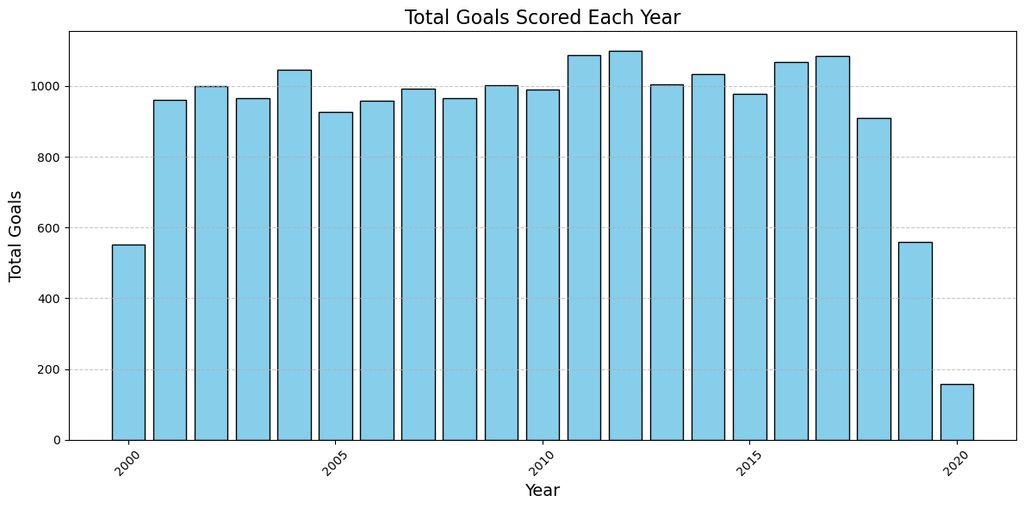

```python
#combining the away goals and home goals scored columns
main_data['Total Goals'] = main_data['FTHG'] + main_data['FTAG']

# Group by year and sum total goals
yearly_goals = main_data.groupby('Year')['Total Goals'].sum().reset_index()

# Rename columns for clarity
yearly_goals.columns = ['Year', 'Total Goals']

# Plot the bar graph
plt.figure(figsize=(12, 6))
plt.bar(yearly_goals['Year'], yearly_goals['Total Goals'], color='skyblue', edgecolor='black')
plt.title('Total Goals Scored Each Year', fontsize=16)
plt.xlabel('Year', fontsize=14)
plt.ylabel('Total Goals', fontsize=14)
plt.xticks(rotation=45)
plt.grid(axis='y', linestyle='--', alpha=0.7)

# Show the plot
plt.tight_layout()
plt.show()
```

### Home vs Away Goals Per Year

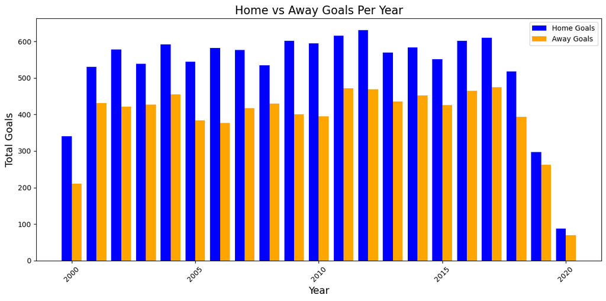

```python
#calculating home and away goals separately
yearly_home_goals = main_data.groupby('Year')['FTHG'].sum().reset_index()
yearly_away_goals = main_data.groupby('Year')['FTAG'].sum().reset_index()

plt.figure(figsize=(12, 6))
plt.bar(yearly_home_goals['Year'] - 0.2, yearly_home_goals['FTHG'], width=0.4, label='Home Goals', color='blue')
plt.bar(yearly_away_goals['Year'] + 0.2, yearly_away_goals['FTAG'], width=0.4, label='Away Goals', color='orange')
plt.title('Home vs Away Goals Per Year', fontsize=16)
plt.xlabel('Year', fontsize=14)
plt.ylabel('Total Goals', fontsize=14)
plt.xticks(rotation=45)
plt.legend()
plt.tight_layout()
plt.show()
```

### Average Goals Per Match

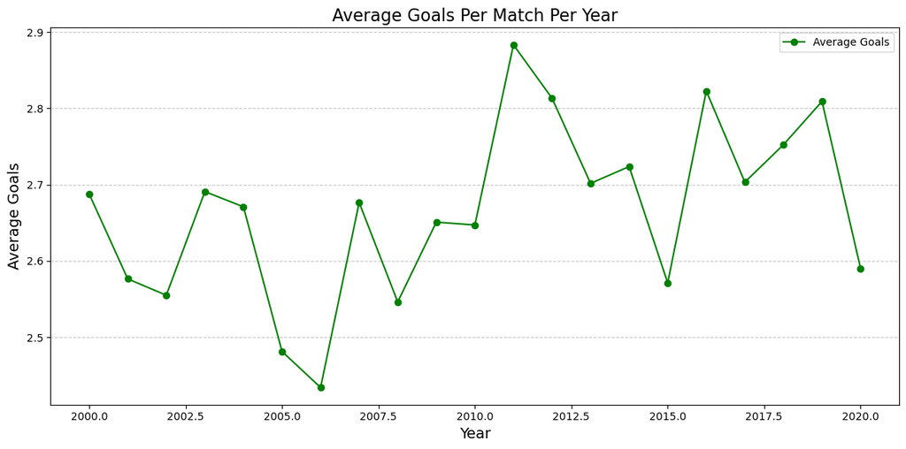

```python
#calculating the average of all goals(away+home) and grouping by each season
main_data['Total Goals'] = main_data['FTHG'] + main_data['FTAG']
average_goals = main_data.groupby('Year')['Total Goals'].mean().reset_index()

plt.figure(figsize=(12, 6))
plt.plot(average_goals['Year'], average_goals['Total Goals'], marker='o', color='green', label='Average Goals')
plt.title('Average Goals Per Match Per Year', fontsize=16)
plt.xlabel('Year', fontsize=14)
plt.ylabel('Average Goals', fontsize=14)
plt.grid(axis='y', linestyle='--', alpha=0.7)
plt.legend()
plt.tight_layout()
plt.show()
```

### Top-Scoring Matches

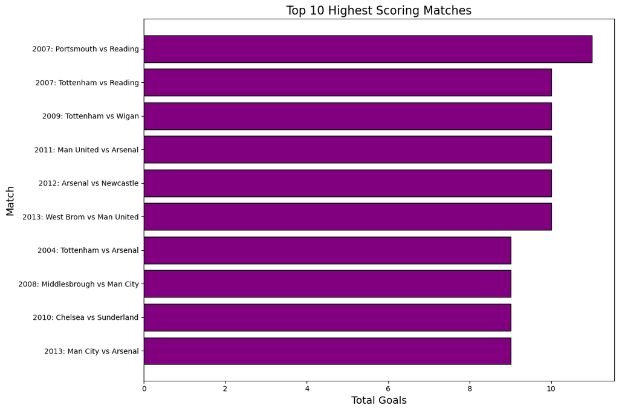

```python
main_data['Total Goals'] = main_data['FTHG'] + main_data['FTAG']

top_matches = main_data.nlargest(10, 'Total Goals')

top_matches['Match'] = (
    top_matches['Year'].astype(str) + ": " +
    top_matches['HomeTeam'] + " vs " +
    top_matches['AwayTeam']
)

plt.figure(figsize=(12, 8))
plt.barh(top_matches['Match'], top_matches['Total Goals'], color='purple', edgecolor='black')

plt.title('Top 10 Highest Scoring Matches', fontsize=16)
plt.xlabel('Total Goals', fontsize=14)
plt.ylabel('Match', fontsize=14)
plt.gca().invert_yaxis()
plt.tight_layout()

plt.show()
```

### Home Percentage win vs Away Percentage Win

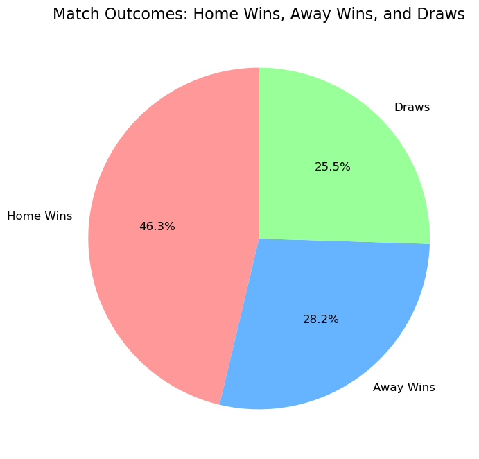

```python
#calculating home wins aand away wins individually
home_wins = (main_data['FTHG'] > main_data['FTAG']).sum()  # Home wins
away_wins = (main_data['FTHG'] < main_data['FTAG']).sum()  # Away wins
draws = (main_data['FTHG'] == main_data['FTAG']).sum()     # Draws

# Total number of matches
total_matches = home_wins + away_wins + draws

# Percentages
home_win_percentage = (home_wins / total_matches) * 100
away_win_percentage = (away_wins / total_matches) * 100
draw_percentage = (draws / total_matches) * 100

# Data for the pie chart
labels = ['Home Wins', 'Away Wins', 'Draws']
percentages = [home_win_percentage, away_win_percentage, draw_percentage]
colors = ['#ff9999', '#66b3ff', '#99ff99']

# Plotting the pie chart
plt.figure(figsize=(8, 8))
plt.pie(percentages, labels=labels, colors=colors, autopct='%.1f%%', startangle=90, textprops={'fontsize': 12})
plt.title('Match Outcomes: Home Wins, Away Wins, and Draws', fontsize=16)
plt.show()
```

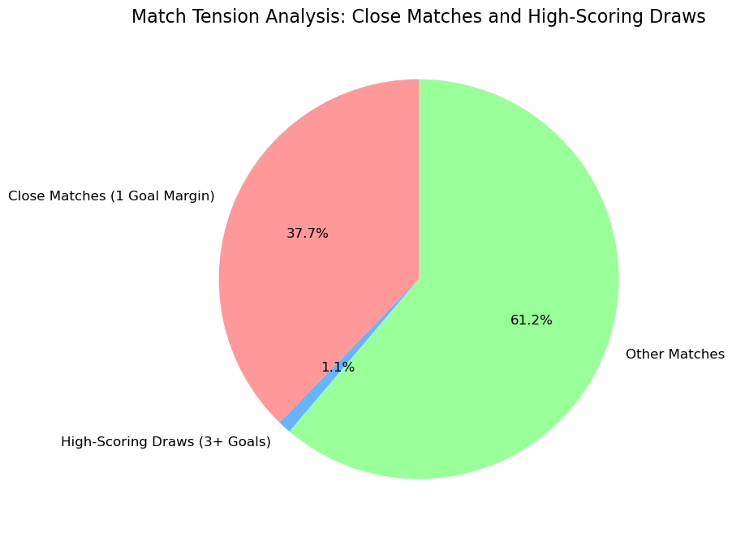

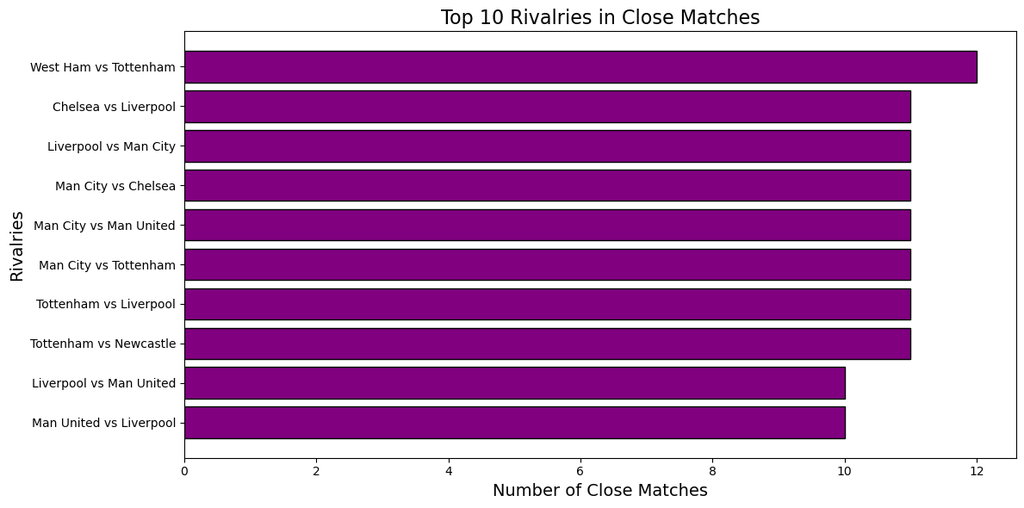

```python
# Define close matches:
# Matches decided by one goal
close_matches = main_data[(abs(main_data['FTHG'] - main_data['FTAG']) == 1)]

# High-scoring draws
high_scoring_draws = main_data[(main_data['FTHG'] == main_data['FTAG']) & (main_data['FTHG'] > 2)]

# Count close matches and high-scoring draws
close_match_count = len(close_matches)
high_scoring_draw_count = len(high_scoring_draws)

# Total matches
total_matches = len(main_data)

# Prepare data for visualization
labels = ['Close Matches (1 Goal Margin)', 'High-Scoring Draws (3+ Goals)', 'Other Matches']
counts = [close_match_count, high_scoring_draw_count, total_matches - (close_match_count + high_scoring_draw_count)]
colors = ['#ff9999', '#66b3ff', '#99ff99']

# Plotting the Pie Chart
plt.figure(figsize=(8, 8))
plt.pie(counts, labels=labels, colors=colors, autopct='%.1f%%', startangle=90, textprops={'fontsize': 12})
plt.title('Match Tension Analysis: Close Matches and High-Scoring Draws', fontsize=16)
plt.show()

# Analyzing close matches further (Top rivalries in close matches)
if 'HomeTeam' in main_data.columns and 'AwayTeam' in main_data.columns:
    rivalries = close_matches.groupby(['HomeTeam', 'AwayTeam']).size().reset_index(name='Count')
    top_rivalries = rivalries.nlargest(10, 'Count')

    # Bar Plot for Top Rivalries
    plt.figure(figsize=(12, 6))
    plt.barh(top_rivalries.apply(lambda x: f"{x['HomeTeam']} vs {x['AwayTeam']}", axis=1),
             top_rivalries['Count'], color='purple', edgecolor='black')
    plt.title('Top 10 Rivalries in Close Matches', fontsize=16)
    plt.xlabel('Number of Close Matches', fontsize=14)
    plt.ylabel('Rivalries', fontsize=14)
    plt.gca().invert_yaxis()
    plt.tight_layout()
    plt.show()
```

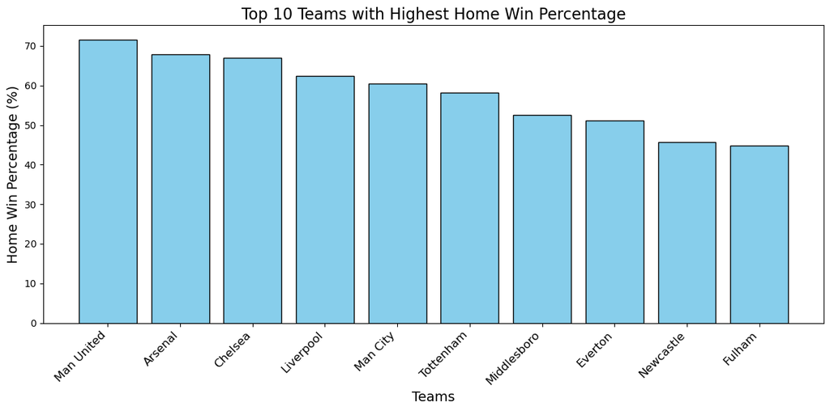

```
If certain teams dominate at home consistently, this insight is valuable for broadcasters to create narratives around fortress-like stadiums.
```

```python
# Filter for home wins
home_wins = main_data[main_data['FTHG'] > main_data['FTAG']]

# Count home wins for each team
home_win_counts = home_wins['HomeTeam'].value_counts()

# Count total home games for each team
total_home_games = main_data['HomeTeam'].value_counts()

# Calculate home win percentage for each team
home_win_percentage = (home_win_counts / total_home_games) * 100

# Sort teams by home win percentage
home_win_percentage = home_win_percentage.sort_values(ascending=False)

# Select top teams for visualization
top_teams = home_win_percentage.head(10)

# Plotting the bar chart
plt.figure(figsize=(12, 6))
plt.bar(top_teams.index, top_teams.values, color='skyblue', edgecolor='black')

# Add labels and title
plt.title('Top 10 Teams with Highest Home Win Percentage', fontsize=16)
plt.xlabel('Teams', fontsize=14)
plt.ylabel('Home Win Percentage (%)', fontsize=14)
plt.xticks(rotation=45, ha='right', fontsize=12)
plt.tight_layout()

# Show the plot
plt.show()

print("If certain teams dominate at home consistently, this insight is valuable for broadcasters to create narratives around fortress-like stadiums.")
```

## Matches where a team was trailing at halftime but won:

```python
def is_come_from_behind_win(row):

    if row["FTR"] == "H" and row["HTHG"] < row["HTAG"]:

        return True

    elif row["FTR"] == "A" and row["HTAG"] < row["HTHG"]:

        return True

    return False

# Filter the dataset

main_data["ComebackWin"] = main_data.apply(is_come_from_behind_win, axis=1)

comeback_wins = main_data[main_data["ComebackWin"]]

# Display the results

print("Matches where a team was trailing at halftime but won:")

print(comeback_wins[["HomeTeam", "AwayTeam", "HTHG", "HTAG", "FTR"]])
```

```
Matches where a team was trailing at halftime but won:
           HomeTeam   AwayTeam  HTHG  HTAG FTR
19          Arsenal   Charlton     1     2   H
32        Tottenham    Everton     1     2   H
45    Middlesbrough    Everton     1     0   A
72            Leeds  Tottenham     0     1   H
111           Leeds  Liverpool     1     2   H
...             ...        ...   ...   ...  ..
7188         Wolves   Man City     0     1   H
7196        Arsenal    Chelsea     1     0   A
7224    Southampton     Wolves     2     0   A
7227        Burnley  Leicester     0     1   H
7229    Aston Villa    Watford     0     1   H

[301 rows x 5 columns]
```

```python
winner_list = pd.read_csv("EPLStandings.csv")

# Melt the dataset for easier processing
melted_data = winner_list.melt(id_vars="Team", var_name="Year", value_name="Position")

# Filter for winners (Position = 1)
winners = melted_data[melted_data["Position"] == 1].sort_values("Year")

# List of winners by year
winners_list = winners[["Year", "Team"]].reset_index(drop=True)

# Count the number of wins for each team
win_counts = winners["Team"].value_counts()

# Display results
print("List of Winners by Year:")
print(winners_list)

print("\nNumber of Wins by Each Team:")
print(win_counts)
```

```
List of Winners by Year:
    Year        Team
0   2000  Man United
1   2001  Man United
2   2002     Arsenal
3   2003  Man United
4   2004     Arsenal
5   2005     Chelsea
6   2006     Chelsea
7   2007  Man United
8   2008  Man United
9   2009  Man United
10  2010     Chelsea
11  2011  Man United
12  2012    Man City
13  2013  Man United
14  2014    Man City
15  2015     Chelsea
16  2016   Leicester

Number of Wins by Each Team:
Team
Man United    8
Chelsea       4
Arsenal       2
Man City      2
Leicester     1
Name: count, dtype: int64
```

### Shot Accuracy

Insight: Comparing shots on target to total shots gives the efficiency of home and away teams in converting attempts into accurate shots.

What you can learn: Which teams (home or away) are more precise in their attacks, and how effective teams are at finishing their opportunities.

```python
# Shot accuracy calculation with division by zero handling
main_data['Home Accuracy'] = np.where(main_data['HS'] != 0, main_data['HST'] / main_data['HS'] * 100, 0)
main_data['Away Accuracy'] = np.where(main_data['AS'] != 0, main_data['AST'] / main_data['AS'] * 100, 0)

print("Shot Accuracy Statistics:")
print(f"Home Team Accuracy: {main_data['Home Accuracy'].mean():.2f}%")
print(f"Away Team Accuracy: {main_data['Away Accuracy'].mean():.2f}%")
```

```
Shot Accuracy Statistics:
Home Team Accuracy: 46.96%
Away Team Accuracy: 46.52%
```

### Referee Bias (Yellow/Red Cards)

Insight: Checking which referees issue the most cards can highlight potential biases or stricter officiating styles.

What you can learn: Do some referees have reputations for strictness? This might affect team strategies or fan perceptions.

```python
# Referee bias analysis
referee_cards = main_data.groupby('Referee')[['HY', 'AY', 'HR', 'AR']].sum()
referee_cards['Total Yellow Cards'] = referee_cards['HY'] + referee_cards['AY']
referee_cards['Total Red Cards'] = referee_cards['HR'] + referee_cards['AR']

print("Referee Bias - Average Cards Given:")
print(referee_cards.sort_values(by='Total Yellow Cards', ascending=False).head())
```

```
Referee Bias - Average Cards Given:
             HY   AY  HR  AR  Total Yellow Cards  Total Red Cards
Referee
M Dean      807  867  34  61                1674               95
M Atkinson  570  717  27  34                1287               61
P Dowd      436  629  23  42                1065               65
A Marriner  447  554  20  35                1001               55
H Webb      426  554  12  21                 980               33
```

### Card Aggression

Insight: Examining the yellow and red cards received by teams indicates their aggression levels and disciplinary records.

What you can learn: Which teams play more aggressively and whether this impacts their performance positively or negatively.

```python
# Sum yellow and red cards for home and away teams separately
home_cards = main_data.groupby('HomeTeam')[['HY', 'HR']].sum()
away_cards = main_data.groupby('AwayTeam')[['AY', 'AR']].sum()

# Rename columns for away team cards
away_cards.columns = ['Away Yellow Cards', 'Away Red Cards']

# Combine home and away cards data
team_cards = home_cards.add(away_cards, fill_value=0)

# Calculate total cards
team_cards['Total Yellow Cards'] = team_cards['HY'] + team_cards['Away Yellow Cards']
team_cards['Total Red Cards'] = team_cards['HR'] + team_cards['Away Red Cards']

# Rename columns for clarity
team_cards.columns = ['Home Yellow Cards', 'Home Red Cards', 'Away Yellow Cards', 'Away Red Cards', 'Total Yellow Cards', 'Total Red Cards']

print("Teams with Most Cards:")
print(team_cards.sort_values(by='Total Yellow Cards', ascending=False).head())
```

```
Teams with Most Cards:
            Home Yellow Cards  Home Red Cards  Away Yellow Cards  \
HomeTeam
Chelsea                  35.0           680.0               22.0
Arsenal                  40.0           620.0               21.0
Man United               35.0           643.0               11.0
Everton                  37.0           590.0               27.0
Tottenham                35.0           628.0               18.0

            Away Red Cards  Total Yellow Cards  Total Red Cards
HomeTeam
Chelsea              487.0              1167.0             57.0
Arsenal              501.0              1121.0             61.0
Man United           462.0              1105.0             46.0
Everton              507.0              1097.0             64.0
Tottenham            466.0              1094.0             53.0
```

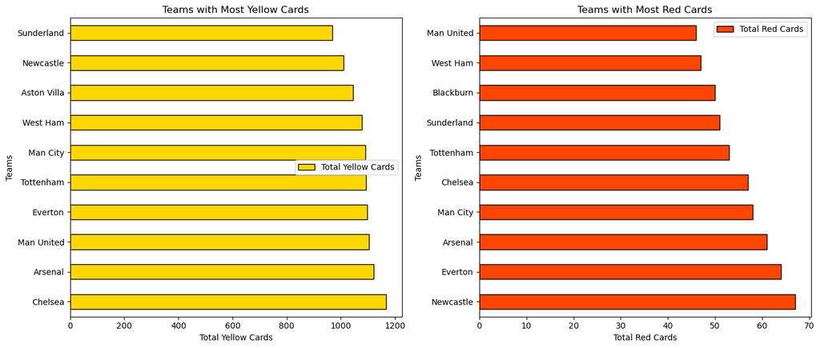

```python
# Plotting the yellow and red cards analysis
fig, ax = plt.subplots(1, 2, figsize=(14, 6))

# Plot for yellow cards
team_cards[['Total Yellow Cards']].sort_values(by='Total Yellow Cards', ascending=False).head(10).plot(kind='barh', ax=ax[0], color='#FFD700', edgecolor='black')
ax[0].set_title('Teams with Most Yellow Cards')
ax[0].set_xlabel('Total Yellow Cards')
ax[0].set_ylabel('Teams')

# Plot for red cards
team_cards[['Total Red Cards']].sort_values(by='Total Red Cards', ascending=False).head(10).plot(kind='barh', ax=ax[1], color='#FF4500', edgecolor='black')
ax[1].set_title('Teams with Most Red Cards')
ax[1].set_xlabel('Total Red Cards')
ax[1].set_ylabel('Teams')

plt.tight_layout()
plt.show()
```

### Most Dominant Teams at Home and Away

What it means: Teams with the highest win rates at home and away reflect dominance in their respective conditions. High home win rates may indicate strong fan support or familiarity with the home pitch, while high away win rates showcase resilience and adaptability.

What you can learn: Which teams are nearly unbeatable at home and which ones perform well under challenging away conditions.

```python
# Home win rate
home_wins = main_data[main_data['FTR'] == 'H'].groupby('HomeTeam').size()
home_matches = main_data.groupby('HomeTeam').size()
home_win_rate = (home_wins / home_matches).sort_values(ascending=False)

# Away win rate
away_wins = main_data[main_data['FTR'] == 'A'].groupby('AwayTeam').size()
away_matches = main_data.groupby('AwayTeam').size()
away_win_rate = (away_wins / away_matches).sort_values(ascending=False)

print("Top Home Teams by Win Rate:")
print(home_win_rate.head())
print("\nTop Away Teams by Win Rate:")
print(away_win_rate.head())
```

```
Top Home Teams by Win Rate:
HomeTeam
Man United    0.716253
Arsenal       0.678571
Chelsea       0.670330
Liverpool     0.624309
Man City      0.604651
dtype: float64

Top Away Teams by Win Rate:
AwayTeam
Man United    0.523416
Chelsea       0.522099
Liverpool     0.456044
Arsenal       0.455801
Man City      0.395349
dtype: float64
```

### Team Discipline

Find the most disciplined and least disciplined teams (based on cards received).

```python
# Sum yellow and red cards for home and away teams separately
home_discipline = main_data.groupby('HomeTeam')[['HY', 'HR']].sum()
away_discipline = main_data.groupby('AwayTeam')[['AY', 'AR']].sum()

# Rename columns for away team discipline
away_discipline.columns = ['Away Yellow Cards', 'Away Red Cards']

# Combine home and away discipline data
discipline = home_discipline.add(away_discipline, fill_value=0)

# Calculate total cards
discipline['Total Cards'] = discipline['HY'] + discipline['HR'] + discipline['Away Yellow Cards'] + discipline['Away Red Cards']

# Rename columns for clarity
discipline.columns = ['Home Yellow Cards', 'Home Red Cards', 'Away Yellow Cards', 'Away Red Cards', 'Total Cards']

print("Most Disciplined Teams:")
print(discipline.sort_values(by='Total Cards').head())

print("\nLeast Disciplined Teams:")
print(discipline.sort_values(by='Total Cards', ascending=False).head())
```

```
Most Disciplined Teams:
             Home Yellow Cards  Home Red Cards  Away Yellow Cards  \
HomeTeam
Blackpool                  2.0            25.0                0.0
Middlesboro                4.0            29.0                1.0
Bradford                   1.0            30.0                0.0
Ipswich                    2.0            47.0                1.0
Cardiff                    2.0            32.0                0.0

             Away Red Cards  Total Cards
HomeTeam
Blackpool              22.0         49.0
Middlesboro            21.0         55.0
Bradford               27.0         58.0
Ipswich                25.0         75.0
Cardiff                42.0         76.0

Least Disciplined Teams:
            Home Yellow Cards  Home Red Cards  Away Yellow Cards  \
HomeTeam
Chelsea                  35.0           680.0               22.0
Arsenal                  40.0           620.0               21.0
Everton                  37.0           590.0               27.0
Man United               35.0           643.0               11.0
Man City                 34.0           645.0               24.0

            Away Red Cards  Total Cards
HomeTeam
Chelsea              487.0       1224.0
Arsenal              501.0       1182.0
Everton              507.0       1161.0
Man United           462.0       1151.0
Man City             446.0       1149.0
```

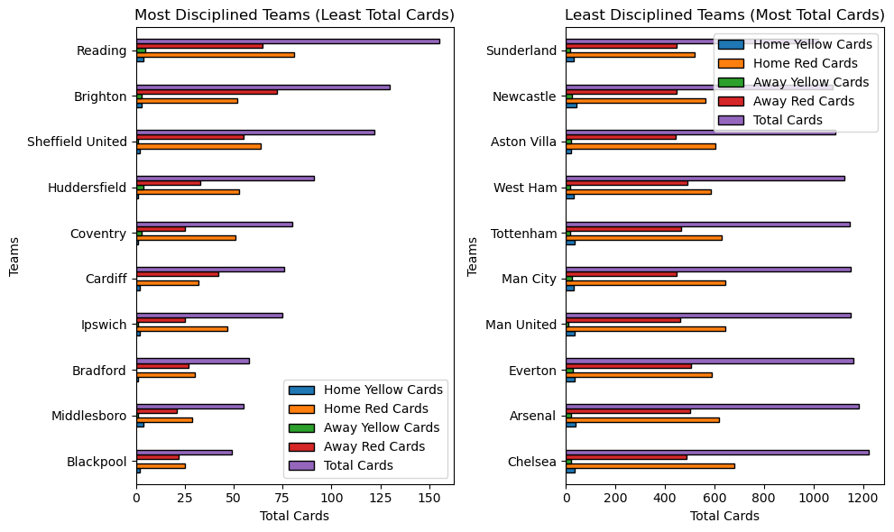

```python
# Plotting the discipline analysis
fig, ax = plt.subplots(1, 2, figsize=(10, 6))

# Plot for most disciplined teams
discipline.sort_values(by='Total Cards').head(10).plot(kind='barh', ax=ax[0], color=['#1f77b4', '#ff7f0e', '#2ca02c', '#d62728', '#9467bd'], edgecolor='black')
ax[0].set_title('Most Disciplined Teams (Least Total Cards)')
ax[0].set_xlabel('Total Cards')
ax[0].set_ylabel('Teams')

# Plot for least disciplined teams
discipline.sort_values(by='Total Cards', ascending=False).head(10).plot(kind='barh', ax=ax[1], color=['#1f77b4', '#ff7f0e', '#2ca02c', '#d62728', '#9467bd'], edgecolor='black')
ax[1].set_title('Least Disciplined Teams (Most Total Cards)')
ax[1].set_xlabel('Total Cards')
ax[1].set_ylabel('Teams')

plt.tight_layout()
plt.show()
```

### Effectiveness of Shots (Conversion Rate)

What it means: The conversion rate measures how efficiently teams convert shots into goals. High conversion rates indicate sharp attacking play, while low rates suggest poor finishing or excellent opposition defense.

What you can learn: Which teams capitalize on their chances the best and which ones struggle to turn opportunities into results.

```python
# Conversion rate
import numpy as np

# Conversion rate calculation with division by zero handling
main_data['Home Conversion Rate'] = np.where(main_data['HS'] != 0, main_data['FTHG'] / main_data['HS'] * 100, 0)
main_data['Away Conversion Rate'] = np.where(main_data['AS'] != 0, main_data['FTAG'] / main_data['AS'] * 100, 0)

avg_home_conversion = main_data['Home Conversion Rate'].mean()
avg_away_conversion = main_data['Away Conversion Rate'].mean()

print(f"Average Home Conversion Rate: {avg_home_conversion:.2f}%")
print(f"Average Away Conversion Rate: {avg_away_conversion:.2f}%")
```

```
Average Home Conversion Rate: 12.01%
Average Away Conversion Rate: 11.45%
```

### Best Defensive Teams

What it means: Teams that concede the fewest goals at home and away are usually strong defensively. This insight highlights their ability to neutralize opposition attacks.

What you can learn: Which teams have solid defenses, making them hard to break down regardless of the opponent or location.

```python
# Defensive performance
home_conceded = main_data.groupby('HomeTeam')['FTAG'].sum() / home_matches
away_conceded = main_data.groupby('AwayTeam')['FTHG'].sum() / away_matches

print("Best Home Defensive Teams (Least Goals Conceded):")
print(home_conceded.sort_values().head())

print("\nBest Away Defensive Teams (Least Goals Conceded):")
print(away_conceded.sort_values().head())
```

```
Best Home Defensive Teams (Least Goals Conceded):
HomeTeam
Man United    0.713499
Liverpool     0.756906
Chelsea       0.799451
Arsenal       0.865385
Man City      0.941860
dtype: float64

Best Away Defensive Teams (Least Goals Conceded):
AwayTeam
Chelsea        0.975138
Man United     1.066116
Arsenal        1.185083
Liverpool      1.186813
Middlesboro    1.210526
dtype: float64
```

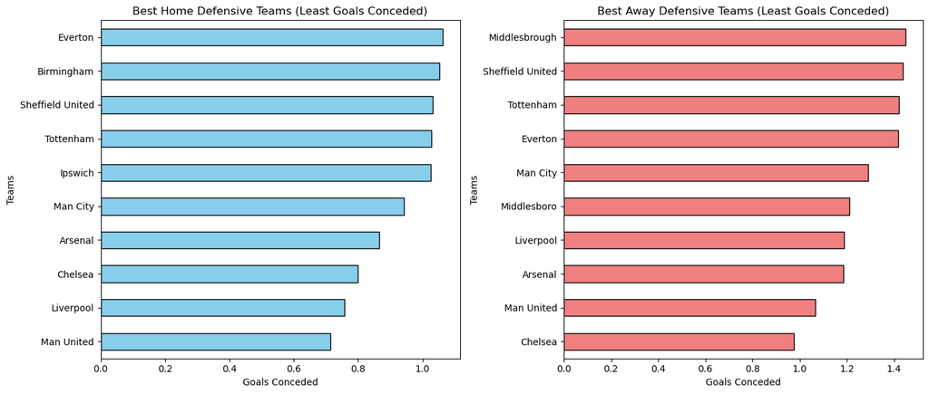

```python
# Plotting the defensive performance
fig, ax = plt.subplots(1, 2, figsize=(14, 6))

# Plot for home defensive performance
home_conceded.sort_values().head(10).plot(kind='barh', ax=ax[0], color='skyblue', edgecolor='black')
ax[0].set_title('Best Home Defensive Teams (Least Goals Conceded)')
ax[0].set_xlabel('Goals Conceded')
ax[0].set_ylabel('Teams')

# Plot for away defensive performance
away_conceded.sort_values().head(10).plot(kind='barh', ax=ax[1], color='lightcoral', edgecolor='black')
ax[1].set_title('Best Away Defensive Teams (Least Goals Conceded)')
ax[1].set_xlabel('Goals Conceded')
ax[1].set_ylabel('Teams')

plt.tight_layout()
plt.show()
```

### Best Aggressive Teams

```python
home_scored=main_data.groupby('HomeTeam')['FTHG'].sum() / home_matches
away_scored = main_data.groupby('AwayTeam')['FTAG'].sum() / away_matches

print("Best Home Aggressive Teams (Most Goals scored):")
print(home_scored.sort_values(ascending=False).head())

print("\nBest Away Aggressive Teams (Most Goals scored):")
print(away_scored.sort_values(ascending=False).head())
```

```
Best Home Aggressive Teams (Most Goals scored):
HomeTeam
Arsenal       2.181319
Man United    2.118457
Chelsea       2.115385
Man City      2.014535
Liverpool     1.964088
dtype: float64

Best Away Aggressive Teams (Most Goals scored):
AwayTeam
Man United    1.647383
Arsenal       1.638122
Chelsea       1.596685
Liverpool     1.549451
Man City      1.505814
dtype: float64
```

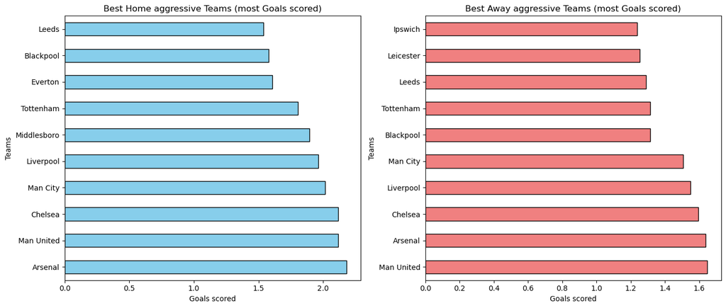

```python
# Plotting the aggressive performance
fig, ax = plt.subplots(1, 2, figsize=(14, 6))

# Plot for home aggressive performance
home_scored.sort_values(ascending=False).head(10).plot(kind='barh', ax=ax[0], color='skyblue', edgecolor='black')
ax[0].set_title('Best Home aggressive Teams (most Goals scored)')
ax[0].set_xlabel('Goals scored')
ax[0].set_ylabel('Teams')

# Plot for away aggressive performance
away_scored.sort_values(ascending=False).head(10).plot(kind='barh', ax=ax[1], color='lightcoral', edgecolor='black')
ax[1].set_title('Best Away aggressive Teams (most Goals scored)')
ax[1].set_xlabel('Goals scored')
ax[1].set_ylabel('Teams')

plt.tight_layout()
plt.show()
```

### Monthly Goal Trends

```python
# Monthly goal trends
monthly_goals = main_data.groupby('Month')[['FTHG', 'FTAG']].sum()
monthly_goals['Total Goals'] = monthly_goals['FTHG'] + monthly_goals['FTAG']

print("Goals Scored Each Month:")
print(monthly_goals.sort_values(by='Total Goals', ascending=False))
```

```
Goals Scored Each Month:
       FTHG  FTAG  Total Goals
Month
12     1352  1062         2414
1      1224   943         2167
9      1189   855         2044
10     1118   842         1960
4      1108   808         1916
8      1071   842         1913
11     1052   809         1861
3       966   666         1632
2       773   562         1335
5       691   474         1165
7       267   227          494
6       266   177          443
```